# Stan SIR Example

Isaac Goldstein

18 July, 2023

# Libraries

```r
library(tidyverse)
library(tidybayes)
library(rstan)
library(posterior)
library(patchwork)
set.seed(236)
options(mc.cores = parallelly::availableCores())
rstan_options(auto_write = TRUE)
```

# Data

Data were generated from a stochastic SIR Model using the Gillespie algorithm. R0 was 1.5, the average time spent in the infectious stage (1/$\nu$) was 7 days. Cases ($O$) were assumed to be noisy realizations of the number of new infectious individuals, modeled as a negative binomial random variable. Let $C(t)$ be cumulative infections at time $t$, then for day $k$:
$$\begin{equation*}
O_{k} \sim \text{Neg-Binom}(\rho \times (C(t_{k}) - C(t_{k-1})), \phi).
\end{equation*}$$
For simulations, $\rho$ was 0.2, and $\phi$ was 57.55. Cases were simulated on a daily time scale, then aggregated to weeks. Here is what the data looks like:

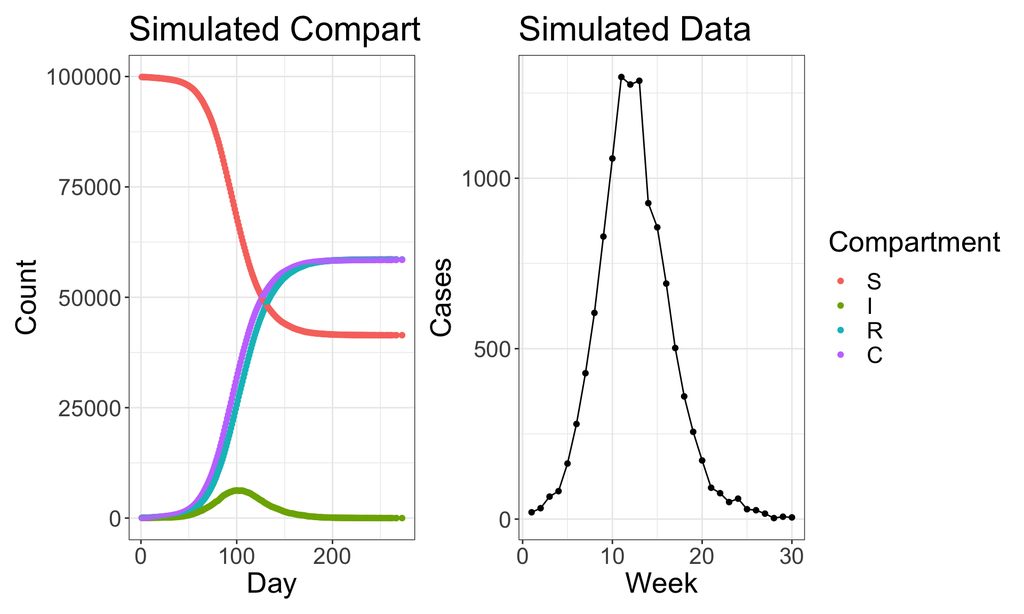

```r
states <- read_csv("https://raw.githubusercontent.com/vnminin/sismid_mcmc_one/main/2023/code/sim_state.csv")

test_data <- read_csv("https://raw.githubusercontent.com/vnminin/sismid_mcmc_one/main/2023/code/sim_data.csv")

state_plot <- states %>%
              dplyr::select(t,S,I,R,C) %>%
              pivot_longer(-t) %>%
              mutate(Compartment = fct_relevel(name, "S", "I", "R", "C")) %>%
              ggplot(aes(x = t, y = value, color = Compartment)) +
              geom_point() +
              theme_bw() +
              theme(text = element_text(size = 20)) +
              ylab("Count") +
              xlab("Day") +
              ggtitle("Simulated Compartments")


data_plot <- test_data %>%
             ggplot(aes(x = week, y = total_cases)) +
             geom_point() +
             geom_line() +
             theme_bw() +
             xlab("Week") +
             ylab("Cases") +
             ggtitle("Simulated Data") +
             theme(text = element_text(size = 20))

combined_plot <- state_plot + data_plot + plot_layout(guides = "collect")

combined_plot
```

# SIR ODE Model

## Latent Dynamics

$N$ is the population size, $\beta$ is the transmission rate, $1/\nu$ is the mean of the infectious period. Latent dynamics of the spread of the Epidemic are described by a system of ODEs.
$$\begin{align*}
\frac{dS}{dt} &= -\beta \times S/N \times I, \\
\frac{dI}{dt} &= \beta \times S/N \times I - \nu \times I, \\
\frac{dR}{dt} &= \nu \times I, \\
\frac{dC}{dt} &= \beta \times S/N \times I.
\end{align*}$$

We put priors on $\nu$ and $R_{0} = \beta/\nu$, the basic reproduction number.

## Initial Counts

We have to specify the initial compartment counts in order to solve the sytem of ODEs. We define fractions of the population in each compartment at time 0 as:
$$\begin{align*}
S_{SIR} &= \frac{S(0)}{N},\\
I_{IR} &= \frac{I(0)}{N-S(0)}.
\end{align*}$$
Then
$$\begin{align*}
S(0) &= S_{SIR} \times N,\\
I(0) &= I_{IR} \times (N - S(0)), \\
R(0) &= N - S(0) - I(0),\\
C(0) &= 1.
\end{align*}$$
We put priors on the fractions in order to preserve the population size. In practice, these are very tight as the parameters are not identifiable from case data.

## Surveillance Model

We use the surveillance model used to generate the data.
$$\begin{equation*}
O_{k} \sim \text{Neg-Binom}(\rho \times (C(t_{k}) - C(t_{k-1})), \phi).
\end{equation*}$$

We put priors on $\rho$ and $\phi$.

## Full Posterior

Let $M(t) = (S(t), I(t), R(t), C(t))$ be the solution to this series of ODEs. Then the posterior of interest is:
$$\begin{equation*}
P(S_{SIR}, I_{IR}, R_{0}, \nu, \rho, \phi|O) \propto P(O|M(t), \rho,
\phi)P(S_{SIR}, I_{IR}, R_{0}, \nu, \rho, \phi).
\end{equation*}$$

# Fitting the model using Rstan

The following code fits the SIR.stan model to this simulated data. The posterior_object contains both the data, as well as parameters specifying the model priors. These are all treated as “data” by stan.

```r
posterior_object <- list(priors_only = FALSE,
                     num_obs = dim(test_data)[1],
                     pop_size = 100000,
                     cases = test_data$total_cases,
                     obs_times = test_data$week,
                     R0_mean = log(1),
                     R0_sd = 0.2,
                     nu_mean = log(1),
                     nu_sd = 0.2,
                     phi_mean = log(50),
                     phi_sd = 0.2,
                     rho_mean = log(0.2),
                     rho_sd = 0.2,
                     frac_S_mean = 6.90755,
                     frac_S_sd = 0.05,
                     frac_I_mean = 0,
                     frac_I_sd = 0.05)

chain = 4
iterations = 1000
seed = 236
thin = 1

posterior_fit <- stan(file = "https://raw.githubusercontent.com/vnminin/sismid_mcmc_one/main/2023/code/SIR.stan",
                  data = posterior_object,
                  seed = seed,
                  iter = iterations,
                  thin = thin,
                  chain = chain)
```

The following code produces draws from the model priors which we use for visualization purposes

```r
prior_object <- list(priors_only = TRUE,
                     num_obs = dim(test_data)[1],
                     pop_size = 100000,
                     cases = test_data$total_cases,
                     obs_times = test_data$week,
                     R0_mean = log(1),
                     R0_sd = 0.2,
                     nu_mean = log(1),
                     nu_sd = 0.2,
                     phi_mean = log(50),
                     phi_sd = 0.2,
                     rho_mean = log(0.2),
                     rho_sd = 0.2,
                     frac_S_mean = 6.90755,
                     frac_S_sd = 0.05,
                     frac_I_mean = 0,
                     frac_I_sd = 0.05)


chain = 4
iterations = 1000
seed = 236
thin = 1

prior_fit <- stan(file = "https://raw.githubusercontent.com/vnminin/sismid_mcmc_one/main/2023/code/SIR.stan",
                  data = prior_object,
                  seed = seed,
                  iter = iterations,
                  thin = thin,
                  chain = chain)
```

```
## [[1]]
## Stan model 'SIR' does not contain samples.
```

# Assessing MCMC Diagnostics

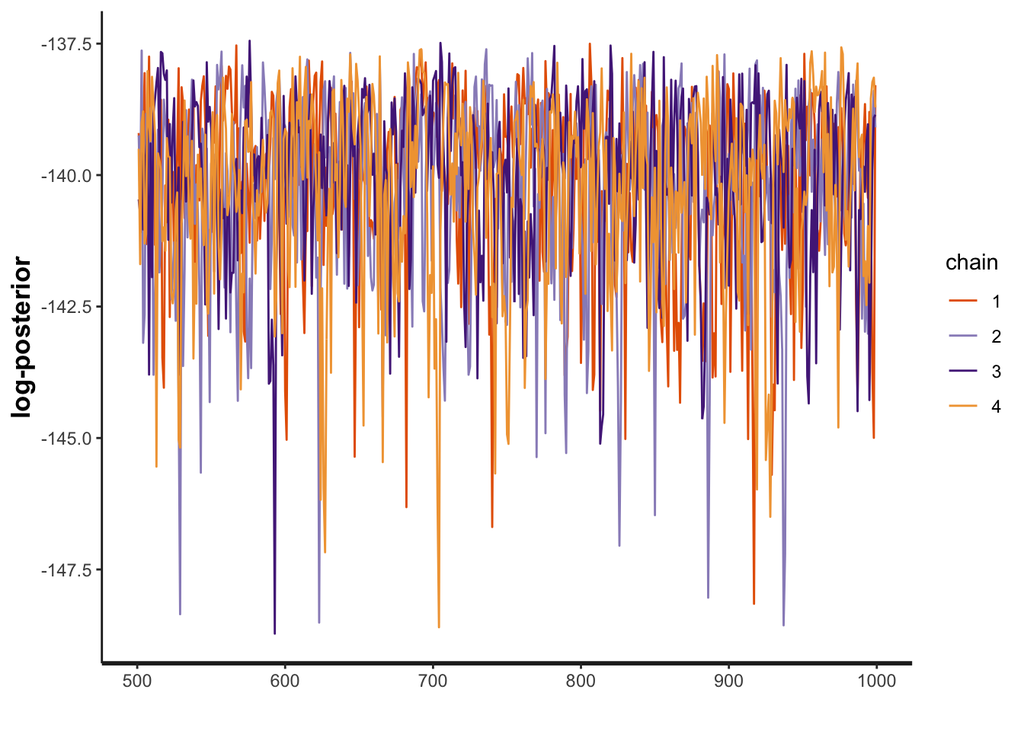

```r
traceplot(posterior_fit, pars = "lp__")
```

We can also summarise Rhat and effective sample size.

```r
summary <- posterior_fit %>%
           as_draws() %>%
           summarise_draws() %>%
           filter(variable != "C_init" & variable != "inits[4]") %>% #the initial value of C is fixed to 1, it naturally has NA values
           summarise(
             min_rhat = min(rhat),
             max_rhat = max(rhat),
             min_ess_bulk = min(ess_bulk),
             max_ess_bulk = max(ess_bulk),
             min_ess_tail = min(ess_tail),
             max_ess_tail = max(ess_tail)
           )

summary
```

```
## # A tibble: 1 × 6
##   min_rhat max_rhat min_ess_bulk max_ess_bulk min_ess_tail max_ess_tail
##      <dbl>    <dbl>        <dbl>        <dbl>        <dbl>        <dbl>
## 1    0.999     1.01         539.        2144.         852.        2020.
```

# Visualizing the results

We can visualize the changes in prior versus posterior distributions. Dots are medians, thick lines are 66% credible intervals, thin lines are 95% credible intervals.

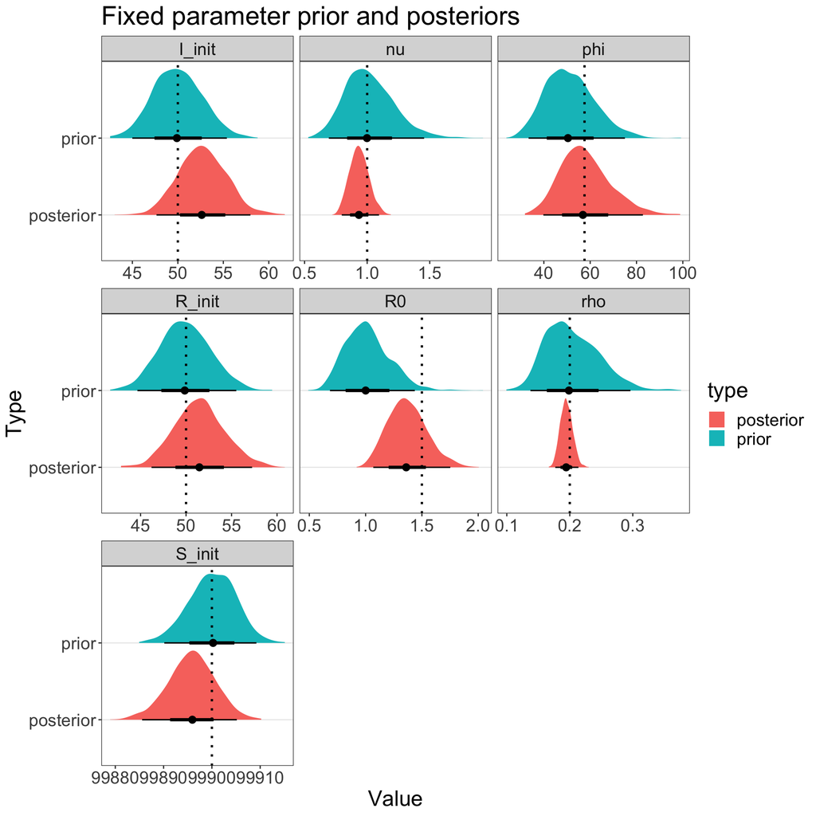

```r
fixed_prior_draws <- prior_fit %>% spread_draws(R0, nu, rho, phi, S_init, I_init, R_init) %>%
                     group_by(.chain, .iteration, .draw) %>%
                     pivot_longer(cols = c(R0, nu, rho, phi, S_init, I_init, R_init)) %>%
                     mutate(type = "prior")
fixed_posterior_draws <- posterior_fit %>% spread_draws(R0, nu, rho, phi, S_init, I_init, R_init) %>%
  group_by(.chain, .iteration, .draw) %>%
  pivot_longer(cols = c(R0, nu, rho, phi, S_init, I_init, R_init)) %>%
  mutate(type = "posterior")

fixed_names <- c("R0",
                 "nu",
                 "rho",
                 "phi",
                 "S_init",
                 "I_init",
                 "R_init")

true_vals <- c(1.5,
               1,
               0.2,
               57.55,
               99900,
               50,
               50)

true_frame <- data.frame(name = fixed_names, true_value = true_vals)


priors_and_posteriors <- rbind(fixed_posterior_draws, fixed_prior_draws) %>%
                         left_join(true_frame, by = "name")


param_plot <- priors_and_posteriors %>%
  ggplot(aes(value, type, fill = type)) +
  stat_halfeye(normalize = "xy")  +
  geom_vline(aes(xintercept = true_value), linetype = "dotted", size = 1) +
  facet_wrap(. ~ name, scales = "free_x") +
  theme_bw() +
  theme(
    panel.grid.major.x = element_blank(),
    panel.grid.minor.x = element_blank()) +
  ggtitle("Fixed parameter prior and posteriors") +
  theme(text = element_text(size = 20)) +
  ylab("Type") +
  xlab("Value")

param_plot
```

We can also visualize the posterior predictive to assess model fit.

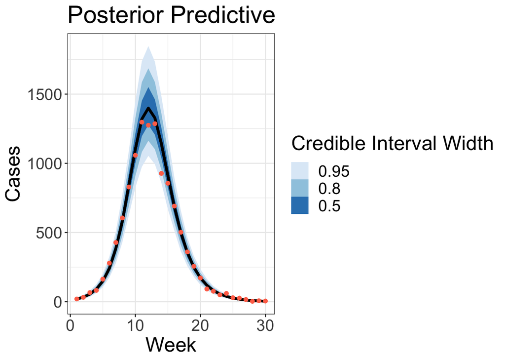

```r
true_cases <- test_data %>%
  dplyr::select(week, total_cases)
posterior_predictive <- posterior_fit %>% spread_draws(gen_cases[i]) %>%
  rename(week = i) %>%
  group_by(week) %>%
  median_qi(gen_cases, .width = c(0.5, 0.8, 0.95)) %>%
  left_join(true_cases, by = "week")

post_pred_plot <- posterior_predictive %>%
  ggplot() +
  geom_lineribbon(aes(x = week, y = gen_cases, ymin = .lower, ymax = .upper, fill = fct_rev(ordered(.width)))) +
  geom_point(mapping = aes(x = week, y = total_cases), color = "coral1") +
  scale_fill_brewer(name = "Credible Interval Width") +
  # scale_fill_manual(values=c("skyblue1", "skyblue2", "skyblue3"), name="fill") +
  theme_bw() +
  ggtitle(paste0("Posterior Predictive")) +
  ylab("Cases") +
  xlab("Week") +
  theme(text = element_text(size = 20))

post_pred_plot
```